# Estudo Dirigido - Glass Identification

Ítalo Gonçalves e José Antonio

06/10/2024

## Sobre a base de dados

A base de dados **Glass Identification** é usada para classificar diferentes tipos de vidro com base em suas propriedades químicas, o que é útil em investigações criminais. Ao analisar fragmentos de vidro encontrados em cenas de crime, é possível identificar sua origem e ligá-los a um local ou suspeito. A base de dados contém variáveis que medem a quantidade de diferentes óxidos químicos presentes nas amostras de vidro, ajudando a distinguir entre os tipos, sendo eles:

- Sódio (Na)
- Magnésio (Mg)
- Alumínio (Al)
- Silício (Si)
- Cálcio (Ca)
- Bário (Ba)
- Ferro (Fe)

O objetivo principal desse estudo é determinar se o vidro pertence a janelas produzidas pelo método de “float glass” ou a outro tipo. Essa classificação é feita com base em padrões químicos, usando três métodos de análise para melhorar a precisão na identificação. Para isso, foi realizada uma análise com três métodos de classificação:

- **Beagle**: Resultados incorretos ao classificar vidros de janelas “float” foram 10, e 19 para vidros que não eram “float”.
- **NN (Nearest Neighbors)**: Houve 12 respostas incorretas para vidros “float” e 16 para vidros que não eram “float”.
- **DA (Discriminant Analysis)**: Este método apresentou 21 erros para vidros “float” e 22 para outros vidros.

A seguir, o gráfico mostra esses resultados:

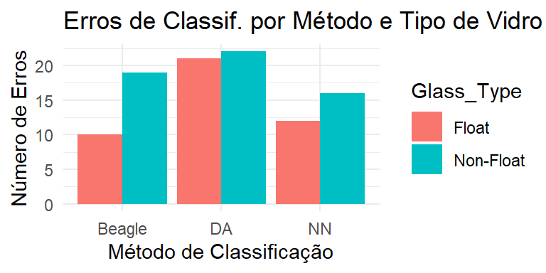

## Dimensionalidade dos Dados

```r
dim(Glass)
```

```
## [1] 214  10
```

Essa base de dados possui 214 amostras e 10 variáveis. E cada variável representa uma característica química ou física dos fragmentos de vidro, sendo a última variável uma classe, sendo o tipo do vidro.

## Análise Estrutural das Variáveis

Utilizando a função `str()` nos dá uma visão geral da base de dados, como o tipo de cada variável e uma amostra de seus valores:

```r
str(Glass)
```

```
## 'data.frame':    214 obs. of  10 variables:
##  $ RI  : num  1.52 1.52 1.52 1.52 1.52 ...
##  $ Na  : num  13.6 13.9 13.5 13.2 13.3 ...
##  $ Mg  : num  4.49 3.6 3.55 3.69 3.62 3.61 3.6 3.61 3.58 3.6 ...
##  $ Al  : num  1.1 1.36 1.54 1.29 1.24 1.62 1.14 1.05 1.37 1.36 ...
##  $ Si  : num  71.8 72.7 73 72.6 73.1 ...
##  $ K   : num  0.06 0.48 0.39 0.57 0.55 0.64 0.58 0.57 0.56 0.57 ...
##  $ Ca  : num  8.75 7.83 7.78 8.22 8.07 8.07 8.17 8.24 8.3 8.4 ...
##  $ Ba  : num  0 0 0 0 0 0 0 0 0 0 ...
##  $ Fe  : num  0 0 0 0 0 0.26 0 0 0 0.11 ...
##  $ Type: Factor w/ 6 levels "1","2","3","5",..: 1 1 1 1 1 1 1 1 1 1 ...
```

A partir dessa análise, podemos ver que todas as variáveis são do tipo numérico, exceto a variável TYPE, que é um fator com 6 níveis, representando as diferentes categorias de vidro.

### Distribuição das Classes

Agora, utilizando a função `table()`, nos permite ver o número de amostras presentes em cada classe de vidro:

```r
table(Glass$Type)
```

```
##
##  1  2  3  5  6  7
## 70 76 17 13  9 29
```

Os resultados mostram a quantidade de amostras em cada 1 das 6 classes de vidro, com isso podemos ver que as classes 1 e 2, correspondentes ao vidro de construção de janelas, são as mais frequentes, enquanto as outras classes têm uma quantidade menor de amostras.

## Integridade da base de dados

Para verificar a integridade da base de dados e identificar se há valores ausentes (NA), utilizamos de duas formas para essa verificação, a função summary(glass), que fornece um resumo das variáveis, permitindo identificar se há ou não valores NA.

```r
summary(Glass)
```

```
##        RI              Na              Mg              Al
##  Min.   :1.511   Min.   :10.73   Min.   :0.000   Min.   :0.290
##  1st Qu.:1.517   1st Qu.:12.91   1st Qu.:2.115   1st Qu.:1.190
##  Median :1.518   Median :13.30   Median :3.480   Median :1.360
##  Mean   :1.518   Mean   :13.41   Mean   :2.685   Mean   :1.445
##  3rd Qu.:1.519   3rd Qu.:13.82   3rd Qu.:3.600   3rd Qu.:1.630
##  Max.   :1.534   Max.   :17.38   Max.   :4.490   Max.   :3.500
##        Si              K                Ca               Ba
##  Min.   :69.81   Min.   :0.0000   Min.   : 5.430   Min.   :0.000
##  1st Qu.:72.28   1st Qu.:0.1225   1st Qu.: 8.240   1st Qu.:0.000
##  Median :72.79   Median :0.5550   Median : 8.600   Median :0.000
##  Mean   :72.65   Mean   :0.4971   Mean   : 8.957   Mean   :0.175
##  3rd Qu.:73.09   3rd Qu.:0.6100   3rd Qu.: 9.172   3rd Qu.:0.000
##  Max.   :75.41   Max.   :6.2100   Max.   :16.190   Max.   :3.150
##        Fe          Type
##  Min.   :0.00000   1:70
##  1st Qu.:0.00000   2:76
##  Median :0.00000   3:17
##  Mean   :0.05701   5:13
##  3rd Qu.:0.10000   6: 9
##  Max.   :0.51000   7:29
```

E como segundo método, de uma forma mais direta, usamos a seguinte função para mostrar se há algum valor NA nesta base:

```r
sum(is.na(Glass))
```

```
## [1] 0
```

Após essa verificação, pode-se dizer que não há dados ausentes na base de dados, ou seja todas as amostras desta base estão completas. Portanto, não é necessário retirar nenhuma amostra.

### Balanceamento dos dados

Para identificar o balanceamento da base de dados, calculamos a porcentagem de cada classe em relação ao total de amostras usando a função prop.table. A fórmula utilizada foi:

```r
round(prop.table(table(Glass$Type)) * 100, 2)
```

```
##
##     1     2     3     5     6     7
## 32.71 35.51  7.94  6.07  4.21 13.55
```

## Problemas de Regressão

```
##    Média Desvio_Padrão
## RI  1.52          0.00
## Na 13.41          0.82
## Mg  2.68          1.44
## Al  1.44          0.50
## Si 72.65          0.77
## K   0.50          0.65
## Ca  8.96          1.42
## Ba  0.18          0.50
## Fe  0.06          0.10
```

### Análise de Outliers

Os outliers podem influenciar significativamente a análise de dados, especialmente em problemas de classificação. Para identificar os outliers na base de dados, criamos gráficos de boxplot para cada uma das variáveis, que podem ajudar a visualizar a distribuição dos dados, identificando valores atípicos (outliers) que se encontram fora dos limites interquartis.

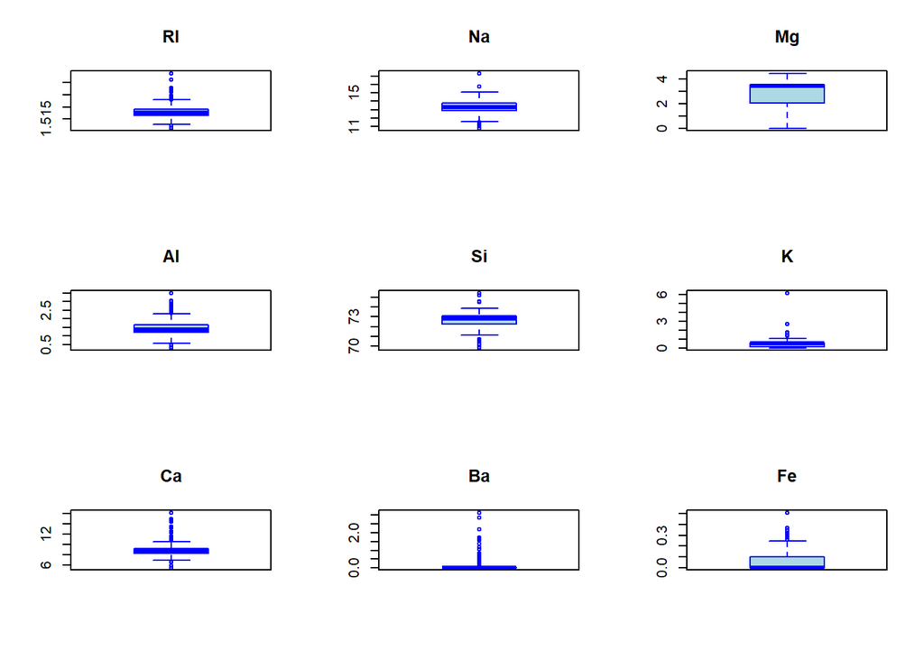

```r
numeric_vars <- Glass[, sapply(Glass, is.numeric)]
par(mfrow = c(3, 3))
for (i in 1:ncol(numeric_vars)) {
  boxplot(numeric_vars[, i], main = colnames(numeric_vars)[i], col = "lightblue", border = "blue")
}
```

Esse código cria boxplots para cada variável numérica da base de dados, o que facilita a identificação de valores fora da faixa esperada. Valores que estão além dos limites superior e inferior do boxplot (geralmente 1,5 vezes o intervalo interquartil) são considerados outliers.

## Análise Descritiva das Variáveis

Na análise descritiva, faremos uma análise descritiva para cada variável, incluindo os valores mínimo, máximo, média e desvio padrão, separando os dados por classes. Aqui, estamos interessados nas características numéricas do conjunto de dados em função da variável de classe (o tipo de vidro). Como podemos ver logo abaixo:

```
## # A tibble: 6 × 37
##   Type  RI_Min RI_Max RI_Média `RI_Desvio Padrão` Na_Min Na_Max Na_Média
##   <fct>  <dbl>  <dbl>    <dbl>              <dbl>  <dbl>  <dbl>    <dbl>
## 1 1       1.51   1.53     1.52            0.00227   12.4   14.8     13.2
## 2 2       1.51   1.53     1.52            0.00380   10.7   14.9     13.1
## 3 3       1.52   1.52     1.52            0.00192   12.2   14.3     13.4
## 4 5       1.51   1.52     1.52            0.00335   11.0   14.0     12.8
## 5 6       1.51   1.52     1.52            0.00312   13.8   17.4     14.6
## 6 7       1.51   1.52     1.52            0.00255   12.0   15.8     14.4
## # ℹ 29 more variables: `Na_Desvio Padrão` <dbl>, Mg_Min <dbl>, Mg_Max <dbl>,
## #   Mg_Média <dbl>, `Mg_Desvio Padrão` <dbl>, Al_Min <dbl>, Al_Max <dbl>,
## #   Al_Média <dbl>, `Al_Desvio Padrão` <dbl>, Si_Min <dbl>, Si_Max <dbl>,
## #   Si_Média <dbl>, `Si_Desvio Padrão` <dbl>, K_Min <dbl>, K_Max <dbl>,
## #   K_Média <dbl>, `K_Desvio Padrão` <dbl>, Ca_Min <dbl>, Ca_Max <dbl>,
## #   Ca_Média <dbl>, `Ca_Desvio Padrão` <dbl>, Ba_Min <dbl>, Ba_Max <dbl>,
## #   Ba_Média <dbl>, `Ba_Desvio Padrão` <dbl>, Fe_Min <dbl>, Fe_Max <dbl>, …
```

Essa tabela mostra como os valores de cada variável variam entre as classes. A partir dela, podemos identificar como as propriedades químicas distinguem os diferentes tipos de vidro.

### Gráficos das Variáveis por Classe

Para visualizar melhor como as variáveis se comportam em relação às classes de vidro, podemos usar gráficos de dispersão, onde mapeamos cada variável em relação à classe.

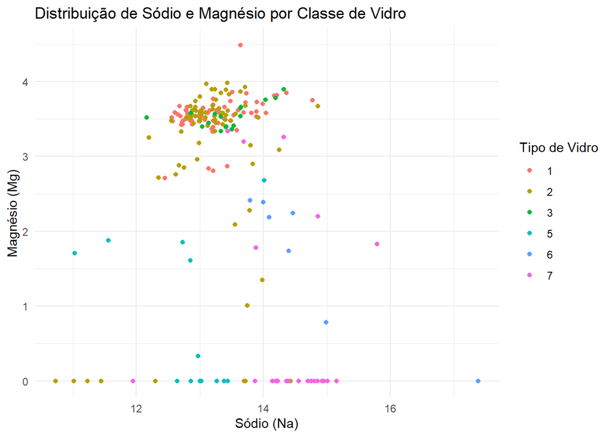

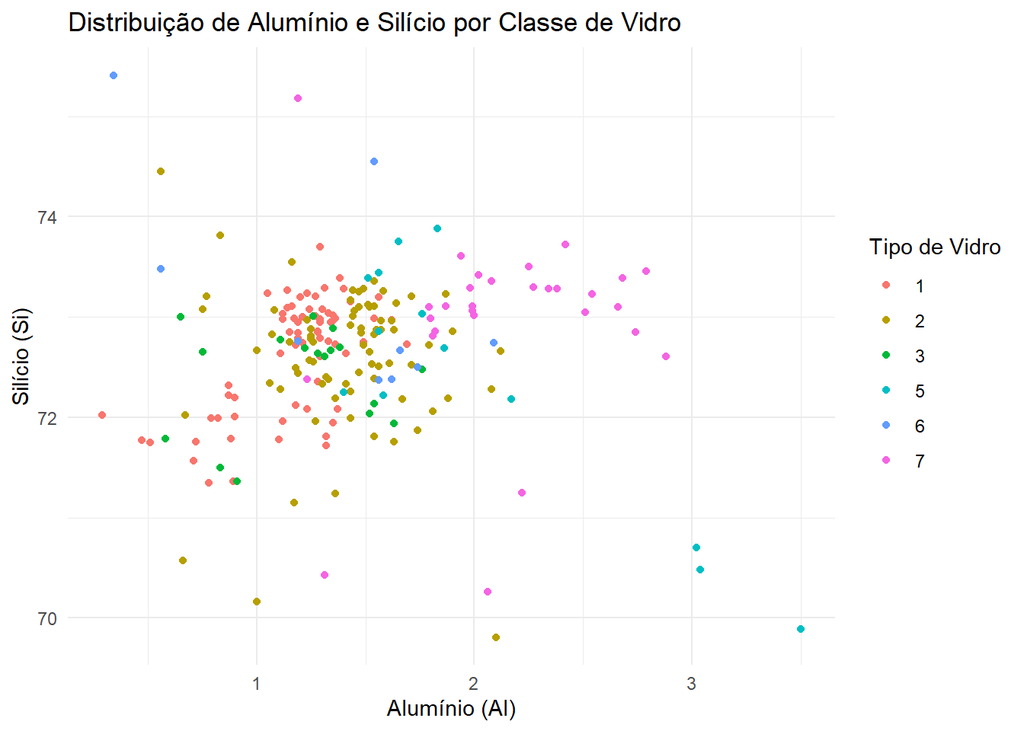

Esses gráficos de dispersão mostram como algumas variáveis se agrupam por classe, o que sugere que as propriedades químicas são bons indicadores para a classificação do vidro.

E os resultados mostram que variáveis como **Na**, **Mg**, **Al** e **Si** têm padrões distintos que ajudam a diferenciar as classes, por isso essa visualização facilita a compreensão de como cada amostra está distribuída e como as classes se separam com base nas características químicas.

## Análise de Correlação

A correlação entre as variáveis numéricas da base de dados pode ajudar a entender como cada característica está relacionada com a classe de vidro, por isso, temos que calcular a matriz de correlação e visualizar um gráfico de correlação, como abaixo:

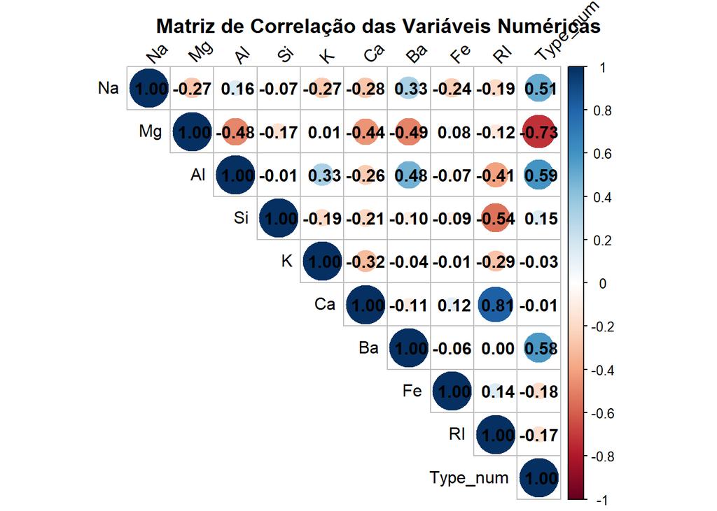

Neste gráfico podemos perceber que a matriz de correlação acima mostra como cada variável numérica está relacionada tanto entre si quanto com a classe de vidro e os coeficientes de correlação variam entre -1 e 1, onde valores próximos de 1 indicam uma correlação positiva forte, e valores próximos de -1 indicam uma correlação negativa forte.

## Pré-processamento e Padrões Esperados

Com essa análise identificamos que a base de dados não possui dados ausentes, mas apresenta desequilíbrio nas classes. Portanto, isso requer a aplicação de técnicas de balanceamento, como oversampling ou undersampling. Além disso, seria interessante testar normalizações nas variáveis numéricas para garantir que as diferenças nas escalas dos dados não influenciem negativamente os modelos.

E sobre os padrãos, espera-se encontrar padrões relacionados à composição química dos vidros que ajudem a distinguir os diferentes tipos de vidro e a mineração de dados pode explorar essas características químicas para fornecer uma classificação precisa, ajudando em contextos forenses como ditos.

## Estudos de artigos sobre a base de dados

[output not shown]